# Logistic Regression

## Odds ratio

$$\large OR = \frac{Odds_{x+c}}{Odds_x} =
\frac{exp(\beta_0+\beta_1(x+c))}{exp(B_0+B_1x)}=exp(c\beta_1)$$

where c > 0 and is the increase of a variable holding all other variables constant.

$$\large \widehat{OR} = exp(c\hat{\beta}_1)$$

Since this is an estimated odds ratio, we have to make CI to make inferences with a level of confidence.

**Wald CI when n >= 40:**

First find $\large \widehat{Var}(\hat{\beta}_1)$ first from estimated covariance matrix. Then:

$$\large exp\left(c\hat{\beta}_1 \pm
cZ_{1-a}\sqrt{\widehat{Var}(\hat{\beta}_1)}\right)$$

Inside the square root should be Var(cB1), but property of variance let us square it and bring it out.

So interpretation should be:  
“With (1-a)100% confidence, the odds of a success change by an amount between”lower” to “upper” times for every c-unit increase in x.”

**Likelihood Ratio (LR) when n < 40:**

$$\large -2log\left(\frac{L(\tilde{\beta}_0, \beta_1 |
y_1,...,y_n)}{L(\hat{\beta}_0,\hat{\beta}_1|y_1,...,y_n)}\right) <
\chi_1^2,_{1-a}$$

where $\tilde{\beta}_0$ is the MLE of $\beta_0$. You also gotta use some iterative numerical procedure to find lower and upper limits. After limits are found, we have to do this:

$$\large exp(c\times lower) < OR< exp(c\times upper)$$

```r
# Odds ratio
exp(mod.fit$coefficients[2])
```

```
##  distance
## 0.8913424
```

```r
exp(-10 * mod.fit$coefficients[2])  #when distance coefficient decreases by -10, the odds of a success changes by 3.15 times for every -10 decrease in x
```

```
## distance
## 3.159035
```

#### **LR Code**

```r
beta.ci <- confint(object = mod.fit, parm = "distance", level = 0.95)  #automatically finds CI with LR
beta.ci
```

```
##       2.5 %      97.5 %
## -0.13181435 -0.09907103
```

```r
rev(exp(-10 * beta.ci))  #OR C.I. for c = -10. #remember we have to multiply the limits by c and take the exp
```

```
##   97.5 %    2.5 %
## 2.693147 3.736478
```

```r
# remove lables with as.numeric()
as.numeric(rev(exp(-10 * beta.ci)))
```

```
## [1] 2.693147 3.736478
```

With the code above, we say that with 95% confidence, the odds increase by between 2.69 and 3.73 when distance is decreased by -10 yards.

#### Wald CI Code

```r
beta.ci <- confint.default(object = mod.fit, parm = "distance",
    level = 0.95)
beta.ci
```

```
##               2.5 %     97.5 %
## distance -0.1313709 -0.0986824
```

```r
rev(1/exp(beta.ci * 10))  #invert OR C.I. for c = 10. We invert cuz it's OR is less than one
```

```
## [1] 2.682701 3.719946
```

##### Wald CI Code By Applying Formula (Hard Way):

```r
beta.ci <- mod.fit$coefficients[2] + qnorm(p = c(0.025, 0.975)) *
    sqrt(vcov(mod.fit)[2, 2])
beta.ci
```

```
## [1] -0.1313709 -0.0986824
```

```r
rev(1/exp(beta.ci * 10))
```

```
## [1] 2.682701 3.719946
```

##### LR Code Without confint(). Super difficult and unecessary

```r
# Examples of how to find profile likelihood ratio
# intervals without confint()

# Example of how to estimate the model logit(pi) = beta~_0
# + beta_1*distance where beta_1*x is held constant and
# beta_1 = -0.12.  The offset() function instructs R to not
# estimate a coefficient for beta1*x1 in the model (treat
# it as a constant).  Because there is only beta_0
# remaining in the model, we need to use the '1' to tell R
# to estimate beta_0.
mod.fit.ex <- glm(formula = good ~ 1 + offset(-0.12 * distance),
    family = binomial(link = logit), data = placekick)
mod.fit.ex$coefficients
```

```
## (Intercept)
##    5.999299
```

```r
logLik(mod.fit.ex)
```

```
## 'log Lik.' -388.0476 (df=1)
```

```r
as.numeric(-2 * (logLik(mod.fit.ex) - logLik(mod.fit)) - qchisq(p = 0.95,
    df = 1))
```

```
## [1] -3.491277
```

```r
######################## EXAMPLE using uniroot() to find
######################## the profile LR interval

# Calculate -2log(Lambda) - 3.84
find.root <- function(beta1, data.set, logLik.denom) {
    mod.fit.temp <- glm(formula = good ~ 1 + offset(beta1 * distance),
        family = binomial(link = logit), data = data.set)
    as.numeric(-2 * (logLik(mod.fit.temp) - logLik.denom) - qchisq(p = 0.95,
        df = 1))
}

# Test
find.root(beta1 = -0.12, data.set = placekick, logLik.denom = logLik(mod.fit))
```

```
## [1] -3.491277
```

```r
find.root(beta1 = -0.1318144, data.set = placekick, logLik.denom = logLik(mod.fit))  # Bound from confint()
```

```
## [1] 0.0002722009
```

```r
find.root(beta1 = -0.09907103, data.set = placekick, logLik.denom = logLik(mod.fit))  # Bound from confint()
```

```
## [1] -0.0002323373
```

```r
# Use uniroot
save.lower <- uniroot(f = find.root, interval = c(-0.15, mod.fit$coefficients[2]),
    data.set = placekick, logLik.denom = logLik(mod.fit))
save.upper <- uniroot(f = find.root, interval = c(mod.fit$coefficients[2],
    -0.05), data.set = placekick, logLik.denom = logLik(mod.fit))
save.lower
```

```
## $root
## [1] -0.1318151
##
## $f.root
## [1] 0.000577683
##
## $iter
## [1] 6
##
## $init.it
## [1] NA
##
## $estim.prec
## [1] 6.103516e-05
```

```r
save.upper
```

```
## $root
## [1] -0.09907579
##
## $f.root
## [1] -0.002576836
##
## $iter
## [1] 8
##
## $init.it
## [1] NA
##
## $estim.prec
## [1] 6.103516e-05
```

```r
# OR interval
round(1/c(exp(10 * save.upper$root), exp(10 * save.lower$root)),
    4)
```

```
## [1] 2.6933 3.7365
```

## Probability of success

We now estimate $\pi$ and make inferences about our estimate with CI’s:

$$\large \hat{\pi} = \frac{exp(\hat{\beta}_0 +
\hat{\beta}_1x_1+...+\hat{\beta}_px_p)}{1+exp(\hat{\beta}_0+\hat{\beta}_1x_1+...+\hat{\beta}_px_p)}$$

#### **Wald**

$$\large \hat{\beta}_0 + \hat{\beta}_1x \pm
Z_{1-a/2}\sqrt{\widehat{Var}(\hat{\beta}_0 + \hat{\beta}_1x)}$$

Estimated variance:

$$\large \widehat{Var}(\hat{\beta}_0+\hat{\beta}_1x) =
\widehat{Var}(\hat{\beta}_0) +
x^2\widehat{Var}(\hat{\beta}_1)+2x\widehat{Cov}(\hat{\beta}_0,
\hat{\beta}_1)$$

and then you transform it to fit logistic regression by the familiar exp(.)/[1+exp(.)]. **This is the Wald’s CI for success.**

$$\large \frac{
exp\left(
\hat{\beta}_0 + \hat{\beta}_1x \pm
Z_{1-a/2}\sqrt{\widehat{Var}(\hat{\beta}_0 + \hat{\beta}_1x)}\right)
}
{
1+exp\left(\hat{\beta}_0 + \hat{\beta}_1x \pm
Z_{1-a/2}\sqrt{\widehat{Var}(\hat{\beta}_0 + \hat{\beta}_1x)}\right)
}$$

#### LR. Use mcprofile package.

```r
install.packages("mcprofile")
library("mcprofile")
```

Basically LR but its harder now czu you’re maximizing with bunch of different variables. Iterative numerical procedures take a long time. BUT if you do it that way, you have to transform the Ci with exp(.)/[1+exp(.)] like the Wald interval.

**R code to estimate** $\large\pi$

```r
linear.pred <- mod.fit$coefficients[1] + mod.fit$coefficients[2] *
    20
linear.pred
```

```
## (Intercept)
##    3.511547
```

```r
as.numeric(exp(linear.pred)/(1 + exp(linear.pred)))
```

```
## [1] 0.9710145
```

```r
# Or, the recommended way
predict.data <- data.frame(distance = 20)
predict(object = mod.fit, newdata = predict.data, type = "link")  #basically using glm() method from mod.fit
```

```
##        1
## 3.511547
```

```r
predict(object = mod.fit, newdata = predict.data, type = "response")
```

```
##         1
## 0.9710145
```

**R code for Wald Interval for** $\large \hat{\pi}$

```r
alpha <- 0.05
linear.pred <- predict(object = mod.fit, newdata = predict.data,
    type = "link", se = TRUE)
linear.pred
```

```
## $fit
##        1
## 3.511547
##
## $se.fit
## [1] 0.1732707
##
## $residual.scale
## [1] 1
```

```r
pi.hat <- exp(linear.pred$fit)/(1 + exp(linear.pred$fit))
CI.lin.pred <- linear.pred$fit + qnorm(p = c(alpha/2, 1 - alpha/2)) *
    linear.pred$se
CI.pi <- exp(CI.lin.pred)/(1 + exp(CI.lin.pred))
round(data.frame(predict.data, pi.hat, lower = CI.pi[1], upper = CI.pi[2]))
```

```
##   distance pi.hat lower upper
## 1       20      1     1     1
```

```r
library(package = mcprofile)
K <- matrix(data = c(1, 20), nrow = 1, ncol = 2)  #B_0 = 1, B_1 = 20
K
```

```
##      [,1] [,2]
## [1,]    1   20
```

```r
# Calculate -2log(Lambda)
linear.combo <- mcprofile(object = mod.fit, CM = K)  #CM = contrast matrix
# CI for beta_0 + beta_1 *x
ci.logit.profile <- confint(object = linear.combo, level = 0.95)
ci.logit.profile
```

```
##
##    mcprofile - Confidence Intervals
##
## level:        0.95
## adjustment:   single-step
##
##    Estimate lower upper
## C1     3.51  3.19  3.87
```

```r
names(ci.logit.profile)
```

```
## [1] "estimate"    "confint"     "CM"          "quant"       "alternative"
## [6] "level"       "adjust"
```

```r
exp(ci.logit.profile$confint)/(1 + exp(ci.logit.profile$confint))
```

```
##       lower    upper
## 1 0.9603165 0.979504
```

```r
exp(ci.logit.profile$estimate)/(1 + exp(ci.logit.profile$estimate))
```

```
##     Estimate
## C1 0.9710145
```

#### Plot of Wald Estimate and CI of success parameter

```r
head(w.n)
```

```
##   distance success trials proportion
## 1       18       2      3     0.6667
## 2       19       7      7     1.0000
## 3       20     776    789     0.9835
## 4       21      19     20     0.9500
## 5       22      12     14     0.8571
## 6       23      26     27     0.9630
```

```r
# Bubbles to show how many were sampled at a particular
# distance
symbols(x = w$distance, y = w$good/n$good, circle = sqrt(n$good),
    inches = 0.5, xlab = "Distance (yards)", ylab = "Estimated probability",
    panel.first = grid(col = "gray", lty = "dotted"))

curve(expr = predict(object = mod.fit, newdata = data.frame(distance = x),
    type = "response"), col = "red", add = TRUE, xlim = c(18,
    66))

# CI bands
ci.pi <- function(newdata, mod.fit.obj, alpha) {
    linear.pred <- predict(object = mod.fit.obj, newdata = newdata,
        type = "link", se = TRUE)
    CI.lin.pred.lower <- linear.pred$fit - qnorm(p = 1 - alpha/2) *
        linear.pred$se
    CI.lin.pred.upper <- linear.pred$fit + qnorm(p = 1 - alpha/2) *
        linear.pred$se
    CI.pi.lower <- exp(CI.lin.pred.lower)/(1 + exp(CI.lin.pred.lower))
    CI.pi.upper <- exp(CI.lin.pred.upper)/(1 + exp(CI.lin.pred.upper))
    list(lower = CI.pi.lower, upper = CI.pi.upper)
}

# test case
ci.pi(newdata = data.frame(distance = 20), mod.fit.obj = mod.fit,
    alpha = 0.05)
```

```
## $lower
##         1
## 0.9597647
##
## $upper
##         1
## 0.9791871
```

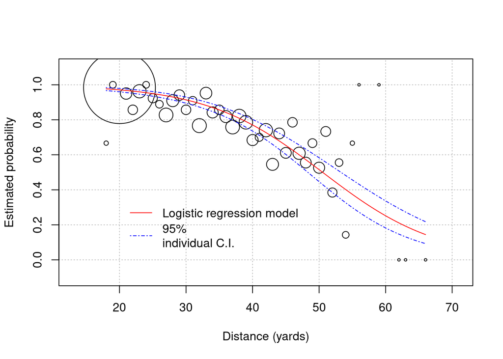

```r
# Plot CI bands
curve(expr = ci.pi(newdata = data.frame(distance = x), mod.fit.obj = mod.fit,
    alpha = 0.05)$lower, col = "blue", lty = "dotdash", add = TRUE,
    xlim = c(18, 66))

curve(expr = ci.pi(newdata = data.frame(distance = x), mod.fit.obj = mod.fit,
    alpha = 0.05)$upper, col = "blue", lty = "dotdash", add = TRUE,
    xlim = c(18, 66))


# Legend
legend(x = 20, y = 0.4, legend = c("Logistic regression model",
    "95%
individual C.I."), lty = c("solid", "dotdash"), col = c("red",
    "blue"), bty = "n")
```

Yes, some are off, but not that many. There are only so many observations at a particular distance value so its hard for the model to fit well with those values. Our model isn’t as bad as we think.

There is also a LR version for the plot thats similar. It will not be coded.